# JonathanWilson-TidyTuesday1

# I wonder if there are any general trends in ratings relating to latitude and longitude…

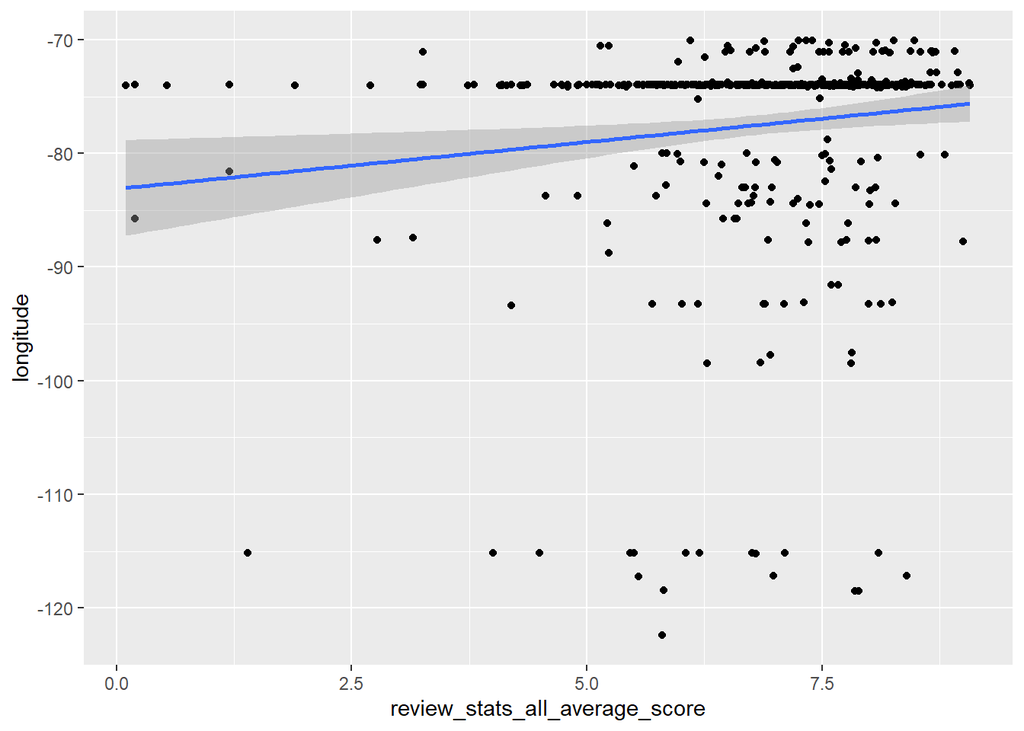

```r
 p1clean %>% ggplot(aes(review_stats_all_average_score, longitude)) + geom_point() + geom_smooth(method = "lm")
```

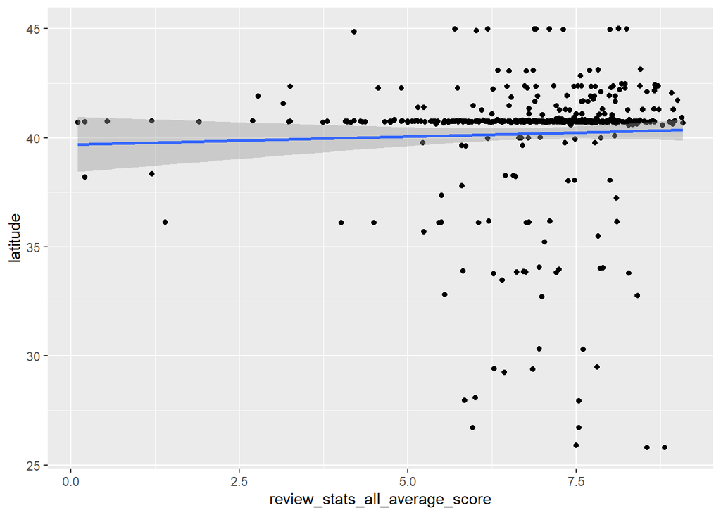

```r
 p1clean %>% ggplot(aes(review_stats_all_average_score, latitude)) + geom_point() +geom_smooth(method = "lm")
```

# In both cases the data from NYC is overwhelming everything else, so lets remove the NYC data and see if anything emerges. # Its becoming clear that the data roughly splits into 2 groups, New york and everywhere else, so I guess the options are to focus on one or the other or compare them.

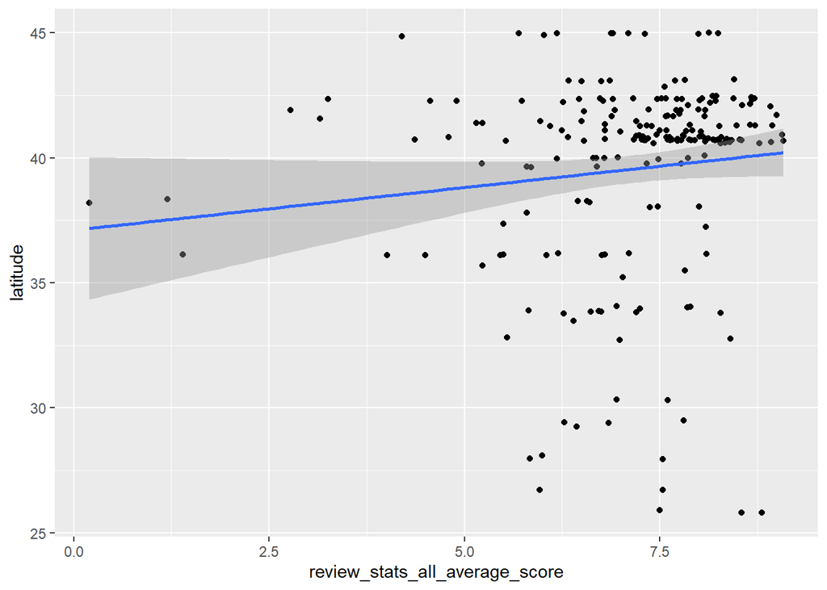

```r
notny <- p1clean %>% filter(city != "New York")
notny %>% ggplot(aes(review_stats_all_average_score, latitude)) + geom_point() +geom_smooth(method = "lm")
```

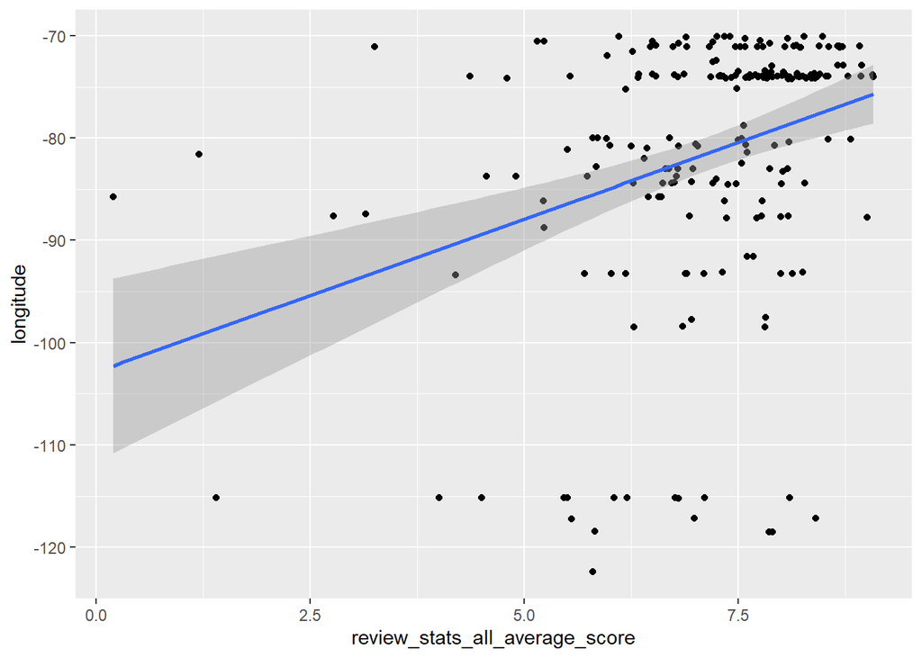

```r
notny %>% ggplot(aes(review_stats_all_average_score, longitude)) + geom_point() +geom_smooth(method = "lm")
```

# There appears to be a reasonable trend between longitude and increased ratings now, suggesting locations on the east coast are generally getting higher ratings. # Lets plot ratings of New York vs “Everybody Else”.

```r
NYC1 = p1clean %>%

  filter(city == "New York")

NYC1
```

```
## # A tibble: 249 x 22
##    name  address1 city    zip country latitude longitude price_level
##    <chr> <chr>    <chr> <dbl> <chr>      <dbl>     <dbl>       <dbl>
##  1 99 C~ 473 Lex~ New ~ 10017 US          40.8     -74.0           1
##  2 Nino~ 39 W 46~ New ~ 10036 US          40.8     -74.0           2
##  3 La P~ 31 E 20~ New ~ 10003 US          40.7     -74.0           2
##  4 Chee~ 2640 Br~ New ~ 10025 US          40.8     -74.0           1
##  5 Sal ~ 2671 Br~ New ~ 10025 US          40.8     -74.0           1
##  6 MAMA~ 2750 Br~ New ~ 10025 US          40.8     -74.0           2
##  7 Bond~ 221 W 4~ New ~ 10036 US          40.8     -74.0           2
##  8 Pats~ 2287 1s~ New ~ 10035 US          40.8     -73.9           2
##  9 LA T~ 101 W 6~ New ~ 10023 US          40.8     -74.0           1
## 10 Perc~ 190 Ble~ New ~ 10012 US          40.7     -74.0           1
## # ... with 239 more rows, and 14 more variables: provider_rating <dbl>,
## #   provider_review_count <dbl>, review_stats_all_average_score <dbl>,
## #   review_stats_all_count <dbl>, review_stats_all_total_score <dbl>,
## #   review_stats_community_average_score <dbl>,
## #   review_stats_community_count <dbl>,
## #   review_stats_community_total_score <dbl>,
## #   review_stats_critic_average_score <dbl>,
## #   review_stats_critic_count <dbl>,
## #   review_stats_critic_total_score <dbl>,
## #   review_stats_dave_average_score <dbl>, review_stats_dave_count <dbl>,
## #   review_stats_dave_total_score <dbl>
```

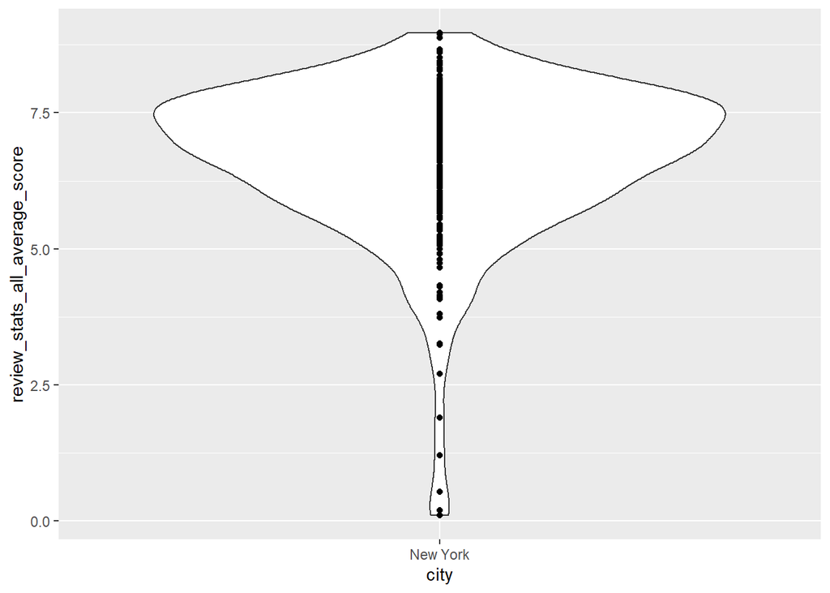

```r
vNYC1 <- NYC1 %>% ggplot(aes(x=city, y=review_stats_all_average_score)) + geom_violin() + geom_point()
vNYC1
```

```r
NYC1mean = p1clean %>%

  filter(city == "New York") %>%

  summarize(score = mean(review_stats_all_average_score))

NYC1mean
```

```
## # A tibble: 1 x 1
##   score
##   <dbl>
## 1  6.66
```

```r
NNYC1mean = p1clean %>%

  filter(city != "New York") %>%

  summarize(score = mean(review_stats_all_average_score))

NNYC1mean
```

```
## # A tibble: 1 x 1
##   score
##   <dbl>
## 1  7.14
```

# Just looking at the means, the non NYC has a higher mean rating.

# Lets create a new column with just a true or false for NYC…

```r
NYCCLEAN <- p1clean %>% mutate(NewYork = city == "New York")
glimpse(NYCCLEAN)
```

```
## Observations: 461
## Variables: 23
## $ name                                 <chr> "Pugsley's Pizza", "Willi...
## $ address1                             <chr> "590 E 191st St", "265 Un...
## $ city                                 <chr> "Bronx", "Brooklyn", "New...
## $ zip                                  <dbl> 10458, 11211, 10017, 1003...
## $ country                              <chr> "US", "US", "US", "US", "...
## $ latitude                             <dbl> 40.85877, 40.70808, 40.75...
## $ longitude                            <dbl> -73.88484, -73.95090, -73...
## $ price_level                          <dbl> 1, 1, 1, 2, 2, 1, 1, 2, 2...
## $ provider_rating                      <dbl> 4.5, 3.0, 4.0, 4.0, 3.0, ...
## $ provider_review_count                <dbl> 121, 281, 118, 1055, 143,...
## $ review_stats_all_average_score       <dbl> 8.011111, 7.774074, 5.666...
## $ review_stats_all_count               <dbl> 27, 27, 9, 2, 1, 5, 17, 1...
## $ review_stats_all_total_score         <dbl> 216.3, 209.9, 51.0, 11.2,...
## $ review_stats_community_average_score <dbl> 7.992000, 7.742308, 5.762...
## $ review_stats_community_count         <dbl> 25, 26, 8, 0, 0, 4, 16, 1...
## $ review_stats_community_total_score   <dbl> 199.8, 201.3, 46.1, 0.0, ...
## $ review_stats_critic_average_score    <dbl> 8.8, 0.0, 0.0, 4.3, 0.0, ...
## $ review_stats_critic_count            <dbl> 1, 0, 0, 1, 0, 0, 0, 0, 1...
## $ review_stats_critic_total_score      <dbl> 8.8, 0.0, 0.0, 4.3, 0.0, ...
## $ review_stats_dave_average_score      <dbl> 7.7, 8.6, 4.9, 6.9, 7.1, ...
## $ review_stats_dave_count              <dbl> 1, 1, 1, 1, 1, 1, 1, 1, 1...
## $ review_stats_dave_total_score        <dbl> 7.7, 8.6, 4.9, 6.9, 7.1, ...
## $ NewYork                              <lgl> FALSE, FALSE, TRUE, TRUE,...
```

# Now lets plot our rating ditribution of NYC vs eveyone else with violin ploys and add our mean rating on there

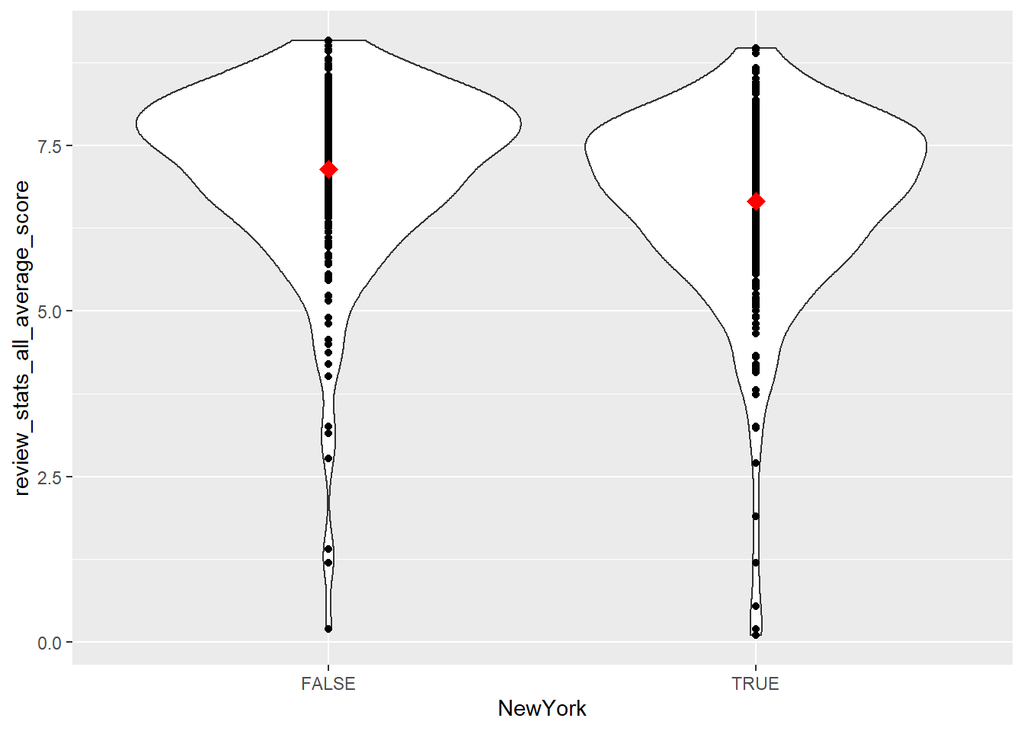

```r
VSNYC1 <- NYCCLEAN %>% ggplot(aes(x=NewYork, y=review_stats_all_average_score)) + geom_violin() + geom_point() + stat_summary(fun.y=mean, geom="point", shape=23, size=3, color= "red", fill="red")
VSNYC1
```

# Looking at our two nice sting rays here it looks like not NYC is winning, but this could be due to NYC being heavily sampled across a whole range of pizza places but the reviewers may be more likely to sample somehwere with a reputation for good pizza outside of the Big Apple